# act_report

### WeRateDogs Twittaer Archive - Act Report

#### WeRateDogs Data

The WeRateDogs Enhanced Twitter archive contains data extracted from 2356 of the 5000+ tweets from the @dog_rates twitter account, posted between November 15, 2015 and August 1, 217. This data is comprised of dog ratings that were taken from the text of the tweet along with the dog name and dog stage if present. The retweet count and favourite count for each tweet were not included in the enhanced archive, and so I had to download this additional data from the twitter account using the tweet ID from the archive. Along with the Twitter data, I also downloaded an image predictions file from Udacity servers containing the top 3 predictions for dog breeds based on the images from the tweets (there can be up to 4).

#### Data Gathering

##### Gathered data from 3 sources, stored in separate files:

1. I downloaded the WeRateDogs Twitter Enhanced archive, manually downloaded from the project page.
2. Image predictions dataset, programmatically downloaded from the Udacity servers.
3. The entire set of each tweets’ JSON data, downloaded by querying the Twitter API using the Tweepy library. The favourite_count and retweet_count were extracted programmatically from this file.

I loaded the 3 raw data files into separate tables: archive, predictions and json_data

#### Insights and Visualizations

There is a strong corelation between retweet and favorite count as seen in the scatter plot. It clearly shows from below that they both follow a similar trend and go in sync together. Chances are that if a user favorites a tweet he might re tweet the same as well and vice versa. Now-a-days heart button is there for this in twitter.

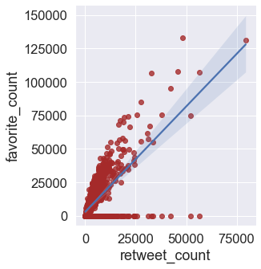

```python
from IPython.display import Image
Image(filename='cor1.png')
```

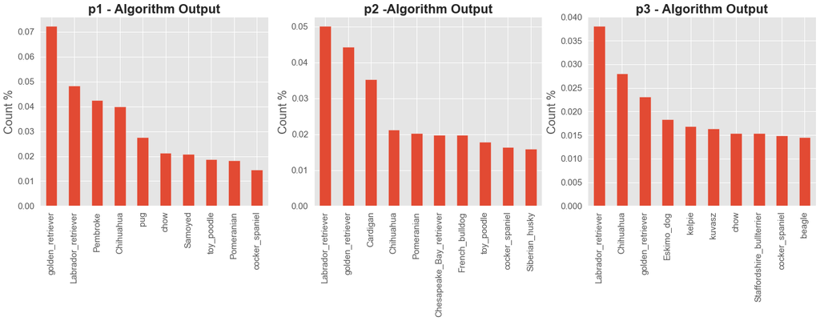

```python
from IPython.display import Image
Image(filename='ImagePredictionResults.png')
```

Most of the dogs fall in the category of puppers(2/3rd of the population). Around 20% of the dogs fall in the category of doggos. Very little floofers tweets. It could be due to the young and unmatured dog is usually cuter than the adult dog..

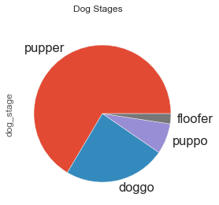

```python
from IPython.display import Image
Image(filename='dog_stages.png')
```

It may be noted that a lot of dog stage data was missing and such cases were excluded from the above viszualization.

```python
Mostly everyone used twitter mobile app for posting dog tweets. Below is the distribution of the source of tweets of we rate dogs data.
```

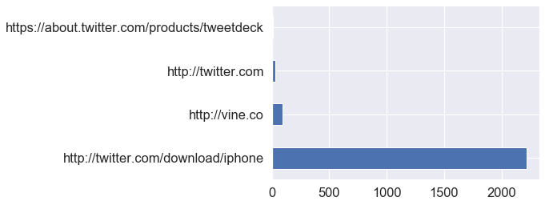

```python
from IPython.display import Image
Image(filename='src.png')
```

Aproximately 95% of the tweets were done from iphone twitter account. Twitter website and TweetDesk is rarely used (less than 1%). Some people share content on twitter via vine app.

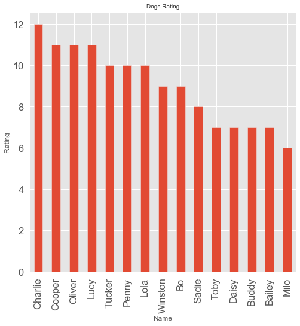

```python
from IPython.display import Image
Image(filename='rating.png')
```

```python
Above chart shows the rating of top 15 dogs. Charli cooper and oliver are the top 3.
```

## Reference

Twitter API Guide: https://www.slickremix.com/docs/how-to-get-api-keys-and-tokens-for-twitter/ Tweepy documentation: https://media.readthedocs.org/pdf/tweepy/latest/tweepy.pdf WeRateDogsTwitter: https://twitter.com/dog_rates?ref_src=twsrc%5Egoogle%7Ctwcamp%5Eserp%7Ctwgr%5Eauthor